# SzCausalSummary

Yuehua Zhu

2023-02-07

## Set up

```r
setwd("/home/Data/Genotype/SzCausal_202211/Summary202301/")
source("../helper.R") #helper functions and library load
source("../notearsMClosses.R")
source("../utils.R")
library(readxl)
library(dplyr)
```

```r
library(ggpubr)
library(reshape2)
library(ggplot2)
set.seed(101)
```

## Dara pre-processing

1. Read new data Read protein data

```r
# proteomic data
synaptosome = read_xlsx("../oneDriveData/LMER-REGRESSION/RESIDUALS+DX_SYNAPTOSOME-PROTEIN-no-pH.xlsx")
phospho = read_xlsx("../oneDriveData/LMER-REGRESSION/RESIDUALS+DX_PHOSPHO-PEPTIDE-2022-11-08.xlsx")
homogenate = read_xlsx("../oneDriveData/LMER-REGRESSION/RESIDUALS+DX_HOMOGENATE-PROTEIN.xlsx")
colnames(synaptosome)[1]="X"
colnames(phospho)[1]="X"
colnames(homogenate)[1]="X"
synaptosome=as.data.frame(synaptosome)
phospho=as.data.frame(phospho)
homogenate=as.data.frame(homogenate)
```

Read spine density data

```r
# spine density
spine.densL3 = read_xlsx("../oneDriveData/spine_density/spine_L3_SML_mean_medianNorm_forVas.xlsx")
spine.densL5 = read_xlsx("../oneDriveData/spine_density/spine_L5_SML_mean_medianNorm_20220604.xlsx")
```

Read phenotype data

```r
# pheno
pheno = read_xlsx("../oneDriveData/metadata/All_Subject_Demographics.xlsx")
pheno = as.data.frame(pheno)
rownames(pheno) = paste0(c("S"), pheno$HU)
```

```r
# mapping IDs
# phosphopeptide_to_phosphosite
phosphoMap_LMER = read.csv("../oneDriveData/LMER-REGRESSION/VAS_LMER-REGRESSION-PHOSPHO-SITE_2022-11-17.csv")
imputed_phos_mapped = readRDS("../savedRDS/imputed_phos_mapped_Vas.RDS")
# uniprot map
protMap_phos = read_xlsx("../oneDriveData/metadata/20220509_uniprot_map_legacy_phos.xlsx")
protMap_hom = read_xlsx("../oneDriveData/metadata/20220920_uniprot_map_legacy_hom.xlsx")
protMap_syn = read_xlsx("../oneDriveData/metadata/20221003_uniprot_map_legacy_syn.xlsx")
```

2. Process spine density data

```r
# combine spine density data
colnames(spine.densL3) = c("patient", "L3.spineS", "L3.spineM", "L3.spineL")
colnames(spine.densL5) = c("patient", "L5.spineS", "L5.spineM", "L5.spineL")
spine.dens = merge(spine.densL3, spine.densL5, by="patient")
spine.dens$patient = paste0(c("S"), spine.dens$patient)
rownames(spine.dens) = spine.dens$patient
# t-scaled spine.dens
spine.dens = tscale(t(spine.dens[,-1]))
```

```r
# get averaged spine density
spine.dens = rbind(spine.dens,
                 (spine.dens[1,]+spine.dens[4,])/2,
                 (spine.dens[2,]+spine.dens[5,])/2,
                 (spine.dens[3,]+spine.dens[6,])/2)
rownames(spine.dens)[7:9] = c("Avg.spineS", "Avg.spineM", "Avg.spineL")
spine.dens[,1:5]
```

```
##                   S537        S567       S621        S659        S665
## L3.spineS   0.79071598  1.70373906  1.0379846  0.40711751 -0.35239506
## L3.spineM   0.74341847  1.21889312 -0.2756114 -0.05084451 -0.36374846
## L3.spineL   0.16157153 -0.03360054 -1.7370161 -0.39026201 -0.36374524
## L5.spineS   0.54341023  0.92139354  1.1607254 -0.18480922  0.26402584
## L5.spineM   0.12056845  0.18182508 -0.4756850  0.40036962 -0.01857248
## L5.spineL  -0.35458365 -0.24950081 -0.3205690  1.93167993  0.68511677
## Avg.spineS  0.66706311  1.31256630  1.0993550  0.11115414 -0.04418461
## Avg.spineM  0.43199346  0.70035910 -0.3756482  0.17476255 -0.19116047
## Avg.spineL -0.09650606 -0.14155068 -1.0287926  0.77070896  0.16068576
```

3. Process protein data

Look at protein data

```r
dim(phospho)
```

```
## [1] 8604   85
```

```r
phospho[1:5,1:5]
```

```
##                                      X       S1543       S1247      S1240
## 1 [K].RLsLESEGAGEGAAASPELSALEEAFRR.[F]  0.08914847  0.06069769 -0.3763341
## 2        [R].QQFTVSSGEsPPLSAGNIYQk.[R]  0.08978403 -0.18648350  0.1182183
## 3              [R].GLYDGPVcEVSVtPk.[T] -0.25367412 -0.44800185  0.1993910
## 4         [R].TGVLLPSSPEAEVPGkLsPk.[Q] -0.18580943  0.25834698  0.4435583
## 5     [R].DVmSDETNNEEtESPSQEFVNITk.[Y]  0.06637524 -0.11895118 -0.3151305
##         S659
## 1  0.1991965
## 2  0.5391897
## 3 -0.3116207
## 4 -0.1365558
## 5  0.2138412
```

```r
dim(homogenate)
```

```
## [1] 6154   85
```

```r
homogenate[1:5,1:5]
```

```
##            X       S1543       S1247      S1240        S659
## 1 A0A075B6I9  1.20958964 -0.20179116  0.2348509 -1.04283998
## 2 A0A075B767  0.32676616  0.40828776  0.3972039 -0.63299760
## 3 A0A087WSZ9 -0.02240467  0.09451659  0.1754651 -0.02535614
## 4 A0A087WW87  1.24859795 -0.08112229 -0.8601148 -0.66167317
## 5 A0A087X1C5  0.01549401 -0.04796556 -0.0296112  0.21076040
```

```r
dim(synaptosome)
```

```
## [1] 4273   71
```

```r
synaptosome[1:5,1:5]
```

```
##            X       S1524     S1542        S659       S1256
## 1 A0A087WW87 -0.07364627 0.2011440 -0.01602870  0.05803797
## 2 A0A0J9YX94 -0.07654129 0.1100552  0.01038487  0.36509269
## 3     A0AVF1 -0.01842234 0.0125747  0.17291865 -0.19032530
## 4     A0AVT1  0.28611163 0.4236436 -0.26265143 -0.36867685
## 5     A0FGR8 -0.32771033 0.3617452  0.22083443 -0.01426039
```

Map protein to Entry name

```r
# map protein to gene
protMap_phos$`Entry name` = gsub("_.*", "", protMap_phos$`Entry name`)
protMap_hom$`Entry Name` = gsub("_.*", "", protMap_hom$`Entry Name`)
protMap_syn$`Entry Name` = gsub("_.*", "", protMap_syn$`Entry Name`)
```

Create Uniprot to Entry name map

```r
hom = data.frame("EntryName" = protMap_hom[protMap_hom$From%in%homogenate$X,]$`Entry Name`,
                 "X" = protMap_hom[protMap_hom$From%in%homogenate$X,]$From)
syn = data.frame("EntryName" = protMap_syn[protMap_syn$From%in%synaptosome$X,]$`Entry Name`,
                 "X" = protMap_syn[protMap_syn$From%in%synaptosome$X,]$From)
Uniprot_Entry_conv = rbind(hom, syn)
Uniprot_Entry_conv = Uniprot_Entry_conv[!duplicated(Uniprot_Entry_conv), ]
head(Uniprot_Entry_conv)
```

```
##   EntryName      X
## 1      PLEC Q15149
## 2     DYHC1 Q14204
## 3     SPTN1 Q13813
## 4     SPTB2 Q01082
## 5      ANK2 Q01484
## 6     MACF1 Q9UPN3
```

Map homogenate and synaptosome IDs

```r
iim = match(homogenate$X, Uniprot_Entry_conv$X)
sum(is.na(iim))
```

```
## [1] 1
```

```r
homogenate[is.na(iim),]
```

[output not shown]

```r
iim = match(synaptosome$X, Uniprot_Entry_conv$X)
sum(is.na(iim))
```

```
## [1] 1
```

```r
synaptosome[is.na(iim),]
```

[output not shown]

Add protein P0DN79 to convert table

```r
Uniprot_Entry_conv = rbind(Uniprot_Entry_conv, c("CBSL", "P0DN79"))
```

```r
iim=match(homogenate$X, Uniprot_Entry_conv$X)
rownames(homogenate) = as.character(Uniprot_Entry_conv$EntryName[iim])

iim=match(synaptosome$X, Uniprot_Entry_conv$X)
rownames(synaptosome) = Uniprot_Entry_conv$EntryName[iim]
```

Look at results

```r
synaptosome$X = NULL
homogenate$X = NULL
synaptosome[1:5,1:5]
```

```
##             S1524     S1542        S659       S1256      S10005
## KV240 -0.07364627 0.2011440 -0.01602870  0.05803797  0.61923701
## PMA6F -0.07654129 0.1100552  0.01038487  0.36509269 -0.10322111
## IFT56 -0.01842234 0.0125747  0.17291865 -0.19032530  0.86425165
## UBA6   0.28611163 0.4236436 -0.26265143 -0.36867685 -0.09275171
## ESYT2 -0.32771033 0.3617452  0.22083443 -0.01426039  0.27757823
```

```r
homogenate[1:5,1:5]
```

```
##             S1543       S1247      S1240        S659        S930
## LV746  1.20958964 -0.20179116  0.2348509 -1.04283998  0.39887085
## PAL4H  0.32676616  0.40828776  0.3972039 -0.63299760 -0.17115722
## TVA30 -0.02240467  0.09451659  0.1754651 -0.02535614  0.02994401
## KV240  1.24859795 -0.08112229 -0.8601148 -0.66167317  0.49930455
## CP2D7  0.01549401 -0.04796556 -0.0296112  0.21076040 -0.09430337
```

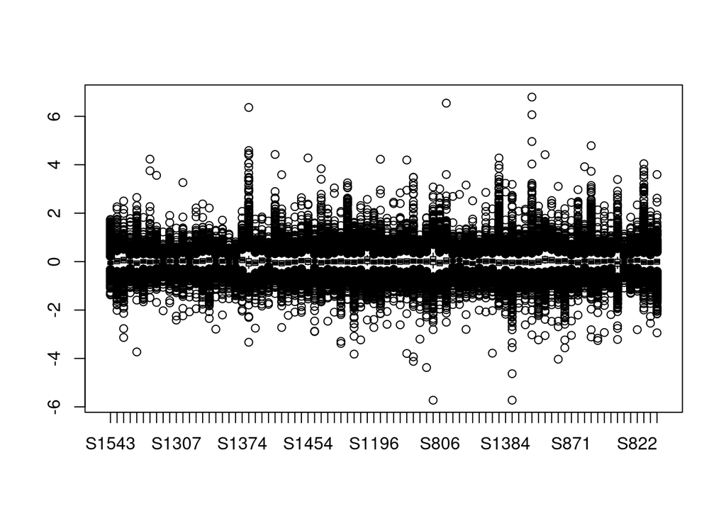

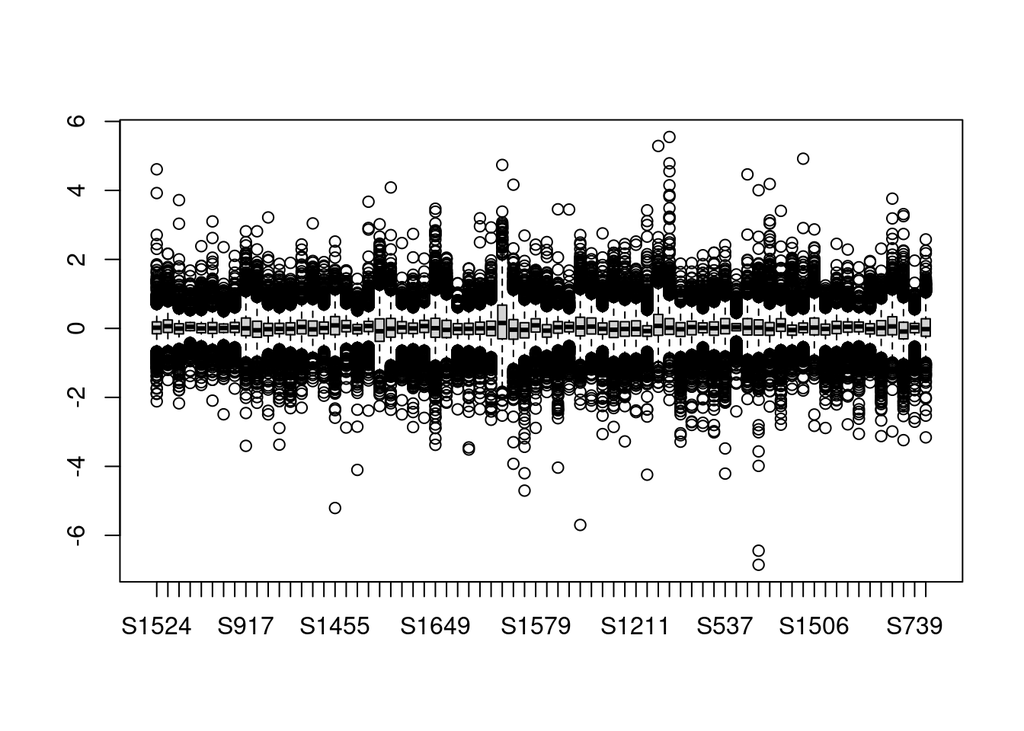

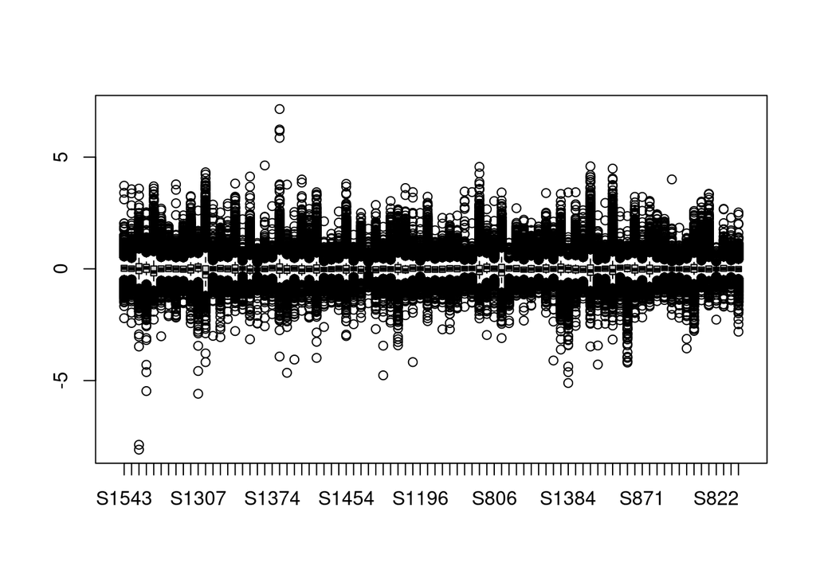

Deal with phospho data

```r
phospho$prot_site = imputed_phos_mapped$prot_site
```

For identical prot_site go to LMER results and pick one with min(q) to keep

```r
phos_LMER = read_xlsx("../oneDriveData/LMER-REGRESSION/LMER-REGRESSION-PHOSPHO-PEPTIDE_2022-11-07.xlsx")
phos_LMER = as.data.frame(phos_LMER)
```

```r
iim = match(phospho$X, phos_LMER$peptide)
phospho$qval = phos_LMER$q[iim]
```

```r
tmp = phospho[!is.na(phospho$prot_site),]
tmp = tmp[order(tmp$prot_site, tmp$qval, decreasing = F),]
tmp = tmp[!duplicated(tmp$prot_site),]
```

```r
phospho = tmp
rownames(phospho) = phospho$prot_site
phospho$X = NULL
phospho$prot_site = NULL
phospho$qval = NULL
```

Phospho site map

```r
load("phospho_site_map.RData")
rownames(phospho) = phospho_site_abbr$rowname
```

Naming of phospho peptides: p + protein ID + phosphosite index

```r
head(rownames(phospho))
```

```
## [1] "pA0FGR8" "pA0JNW5" "pA1IGU5" "pA1Z1Q3" "pA2A288" "pA2A2V5"
```

4. tscale on all protein data (since this is log transformed)

```r
# tscale
homogenate = tscale(homogenate)
phospho = tscale(phospho)
synaptosome = tscale(synaptosome)
```

5. Combine all proteins

```r
rownames(synaptosome) = paste0(rownames(synaptosome), c('.syn'))

comCol = commonColumns(phospho, synaptosome)
intersectProt = rbind(phospho[,comCol], homogenate[,comCol], synaptosome[,comCol])

comCol = commonColumns(intersectProt, spine.dens)
intersectProt = rbind(phospho[,comCol], homogenate[,comCol], synaptosome[,comCol])
```

6. Save the protein results

```r
saveRDS(homogenate, "savedRDS/homogenate_LMERtscaled.RDS")
saveRDS(synaptosome, "savedRDS/synaptosome_LMERtscaled.RDS")
saveRDS(phospho, "savedRDS/phospho_LMERtscaled.RDS")
saveRDS(intersectProt, "savedRDS/intersectProt_LMERtscaled.RDS")
```

## Look at spine density and disease prediction

1. Average spine density
- Diagnosis

```r
df = melt(as.matrix(spine.dens))
colnames(df) = c("type", "subj", "value")
df$pheno = pheno[as.character(df$subj),]$Group #since the subject id is actually a number if may get autoconverted
```

plot

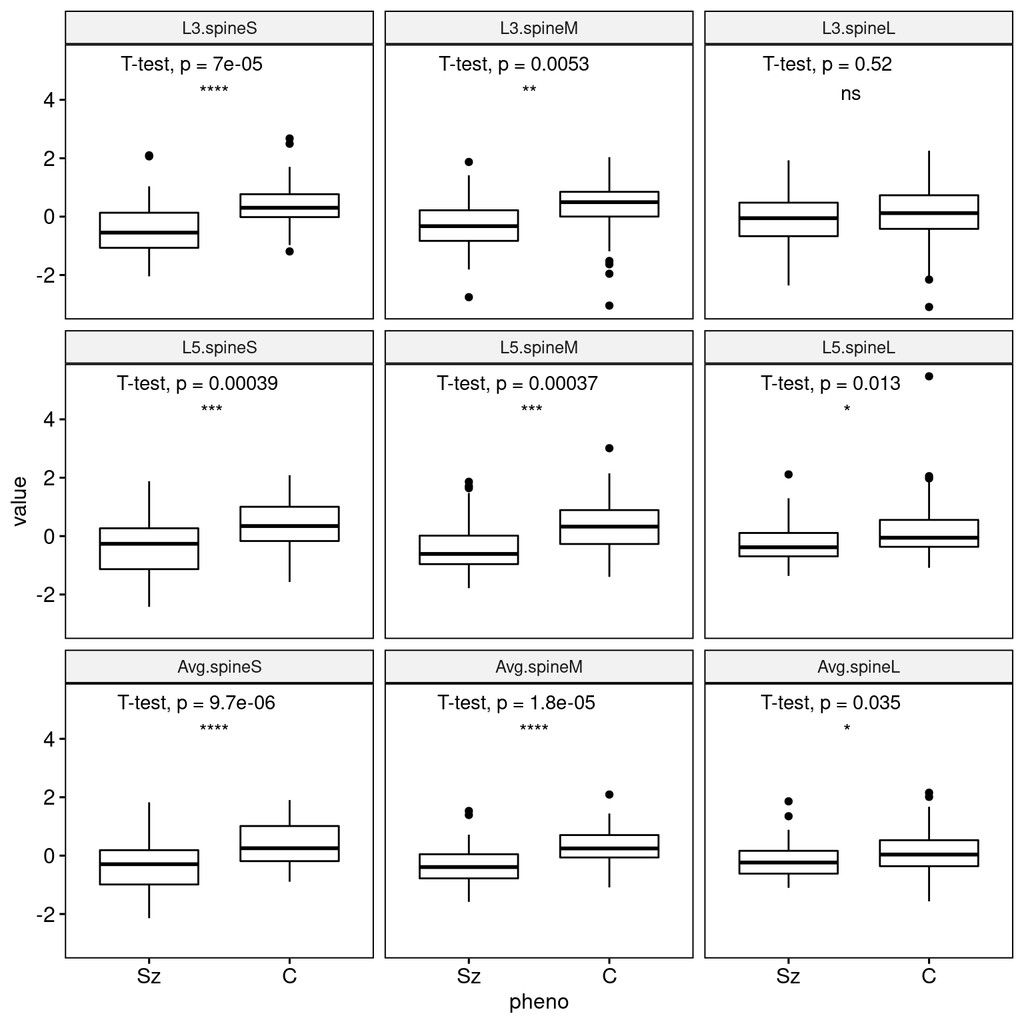

```r
p = ggboxplot(df, x = "pheno", y = "value", facet.by = "type")+
    stat_compare_means(method = "t.test", label.x = 1, label.y = 5) +
    stat_compare_means(aes(label = ..p.signif..), method = "t.test", label.y = 4, label.x = 1.4)
facet(p, facet.by = "type", ncol = 3)
```

```r
#correlation between spine.dense and diagnosis
cor.result = data.frame()
for(i in 1:9) {
    cor=cor.test(as.numeric(spine.dens[i,]), as.numeric(pheno[colnames(spine.dens),]$Group=="C"))
    tmp=t(melt(unlist(cor)))
    cor.result=rbind(cor.result, tmp)
}
```

```r
rownames(cor.result)=rownames(spine.dens)
corR=as.data.frame(cor.result)
corR$statistic.t=as.numeric(corR$statistic.t)
corR$estimate.cor=as.numeric(corR$estimate.cor)
corR$p.value=as.numeric(corR$p.value)
```

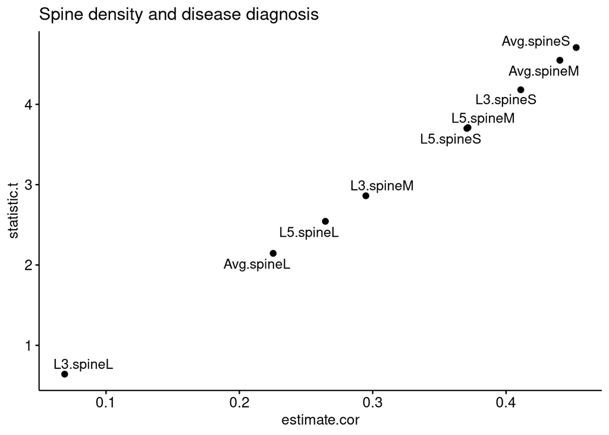

```r
ggscatter(corR, "estimate.cor", "statistic.t", label = rownames(corR), repel = T, title = "Spine density and disease diagnosis")
```

```r
protein = intersectProt
spine.dens = spine.dens[,colnames(intersectProt)]
pheno = pheno[colnames(protein),]
multi_Avg=data.frame("patient"=colnames(spine.dens))
multi_L3=data.frame("patient"=colnames(spine.dens))
multi_L5=data.frame("patient"=colnames(spine.dens))
```

Run cv.glmnet (with keep=T) 100 times and average all the mininmum cm results.

```r
for (i in 1:100) {
    # print(paste0("working on: ", i, "..."))
    gres = cv.glmnet(y=spine.dens[7,], x=t(protein), family="gaussian", type.measure="mse", alpha=0.9, keep = T)
    multi_Avg=cbind(multi_Avg, gres$fit.preval[,gres$cvm == min(gres$cvm)])

    gres = cv.glmnet(y=spine.dens[1,], x=t(protein), family="gaussian", type.measure="mse", alpha=0.9, keep = T)
    multi_L3=cbind(multi_L3, c(gres$fit.preval[,gres$cvm == min(gres$cvm)]))

    gres = cv.glmnet(y=spine.dens[4,], x=t(protein), family="gaussian", type.measure="mse", alpha=0.9, keep = T)
    multi_L5=cbind(multi_L5, c(gres$fit.preval[,gres$cvm == min(gres$cvm)]))
}
```

```r
surrogateAvg = apply(multi_Avg[,-1], 1, mean)
surrogateL3 = apply(multi_L3[,-1], 1, mean)
surrogateL5 = apply(multi_L5[,-1], 1, mean)
```

3. look at prediction results

```r
avg = data.frame("surrogate_prediction" = surrogateAvg, "real"=spine.dens[7,])
l3 = data.frame("surrogate_prediction" = surrogateL3, "real"=spine.dens[1,])
l5 = data.frame("surrogate_prediction" = surrogateL5, "real"=spine.dens[4,])
l3p_l5 = data.frame("surrogate_prediction" = surrogateL3, "real"=spine.dens[4,])
l5p_l3 = data.frame("surrogate_prediction" = surrogateL5, "real"=spine.dens[1,])
l3p_l5p = data.frame("surrogate_prediction" = surrogateL3, "real"=surrogateL5)
```

```r
PredictScatter <- function(data, title=NULL, xlab=NULL, ylab=NULL, ...) {
    p = ggscatter(data, "real", "surrogate_prediction",
               ylim=c(-0.5,0.5), xlim=c(-2.3,2),
               add = "reg.line", conf.int = TRUE, # Add confidence interval
               cor.coef = TRUE, # Add correlation coefficient. see ?stat_cor
               cor.coeff.args = list(method = "pearson", label.x = -2.3, label.y = 0.4, label.sep = "\n", size=3),
               title = title,
               xlab = xlab,
               ylab = ylab)
    p
}
```

```r
p1 = PredictScatter(avg,
                    title = "Avg.predict vs Avg.real",
                    xlab = "Avg.real", ylab = "Avg.surrogate_prediction")

p2 = PredictScatter(l3,
                    title = "L3.predict vs L3.real",
                    xlab = "L3.real", ylab = "L3.surrogate_prediction")
p3 = PredictScatter(l5,
                    title = "L5.predict vs L5.real",
                    xlab = "L5.real", ylab = "L5.surrogate_prediction")
p4 = PredictScatter(l3p_l5,
                    title = "L3.predict vs L5.real",
                    xlab = "L5.real", ylab = "L3.surrogate_prediction")
p5 = PredictScatter(l5p_l3,
                    title = "L5.predict vs L3.real",
                    xlab = "L3.real", ylab = "L5.surrogate_prediction")
p6 = PredictScatter(l3p_l5p,
                    title = "L3.predict vs L5.predict",
                    xlab = "L5.surrogate_prediction", ylab = "L3.surrogate_prediction")
```

Predict vs real spine density

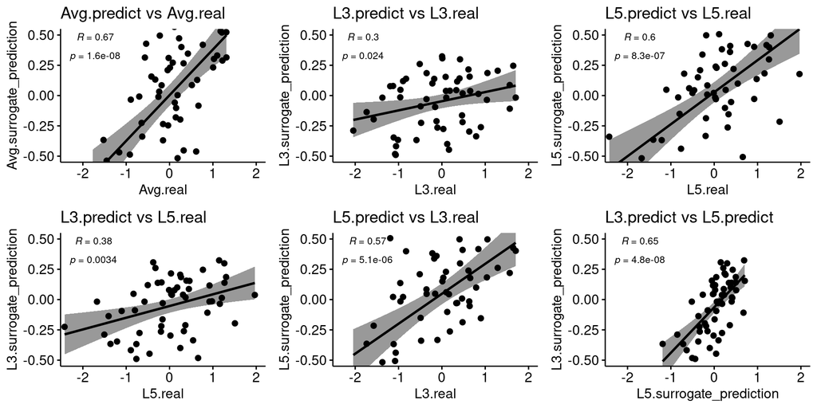

```r
ggarrange(p1, p2, p3, p4, p5, p6, ncol = 3, nrow = 2)
```

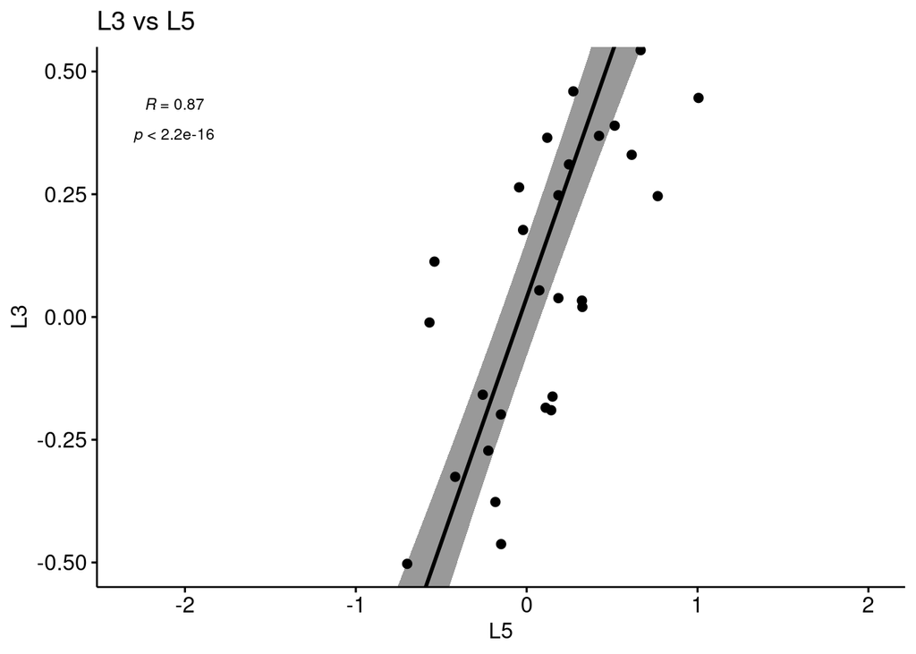

```r
l3_l5 = data.frame("surrogate_prediction" = spine.dens[4,], "real" = spine.dens[7,])
p = PredictScatter(l3_l5,
               title = "L3 vs L5",
               xlab = "L5", ylab = "L3")
p
```

Predict vs real spine density and diagnosis

```r
tmp = rbind(spine.dens, surrogateL3, surrogateL5, surrogateAvg)
df = melt(as.matrix(tmp))
head(df)
```

```
##        Var1  Var2      value
## 1 L3.spineS S1543  1.5656245
## 2 L3.spineM S1543  0.4419577
## 3 L3.spineL S1543 -0.2453814
## 4 L5.spineS S1543  0.4461277
## 5 L5.spineM S1543 -1.1905777
## 6 L5.spineL S1543 -0.9467829
```

```r
colnames(df) = c("type", "subj", "value")
df$pheno = pheno[as.character(df$subj),]$Group #since the subject id is actually a number if may get autoconverted
head(df)
```

```
##        type  subj      value pheno
## 1 L3.spineS S1543  1.5656245     C
## 2 L3.spineM S1543  0.4419577     C
## 3 L3.spineL S1543 -0.2453814     C
## 4 L5.spineS S1543  0.4461277     C
## 5 L5.spineM S1543 -1.1905777     C
## 6 L5.spineL S1543 -0.9467829     C
```

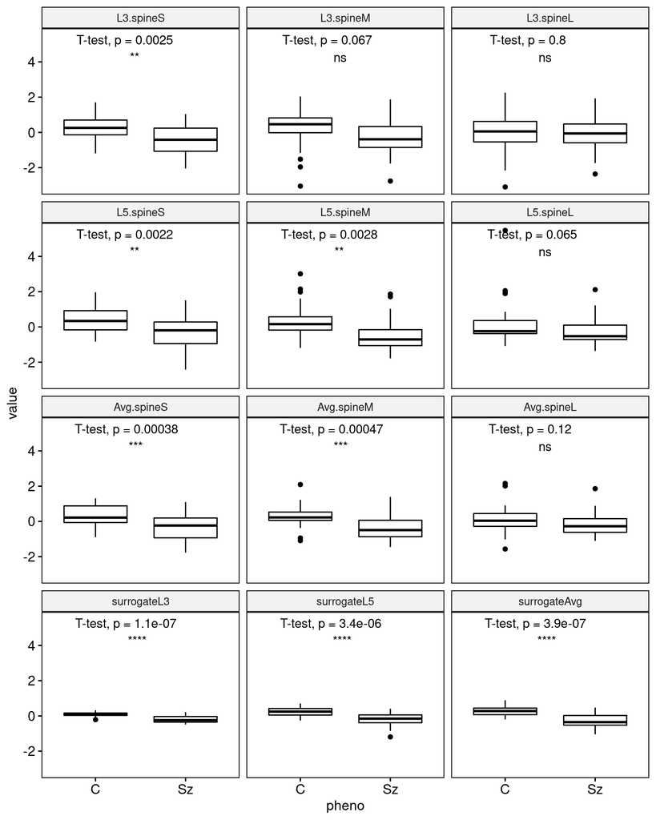

```r
p = ggboxplot(df, x = "pheno", y = "value", facet.by = "type")+
    stat_compare_means(method = "t.test", label.x = 1, label.y = 5) +
    stat_compare_means(aes(label = ..p.signif..), method = "t.test", label.y = 4, label.x = 1.4)
facet(p,facet.by = "type", ncol=3)
```